# TAE - Unit 1 - Recitation

GT

14 avril 2016

## Unit 1 - Recitation

### The importance of Food and Nutrition

Good nutrition is an important part of leading a healthy lifestyle. Malnutrition can result in obesity. More than 35% of American adults are obese. The trends Worldwide are no different. Obesity is one of today’s visible public health problems.  
So good nutrition is essential for an overall healthy lifestyle. We have access to hundreds of nutrition and weight loos applications. These apps are mostly powered by the United States Departement of Agricultural, USDA, food database. These database is about over 7000 food items including the amount of calories and nutrients.

### Working with Data in R

Start by reading the dataset `USDA.csv`, which contains all foods in the USDA database in 100 grams amounts.

Use the function read.csv() and save the output to a data frame, USDA Learn about the data using the functino str()

```r
USDA = read.csv("USDA.csv")
str(USDA)
```

```
## 'data.frame':    7058 obs. of  16 variables:
##  $ ID          : int  1001 1002 1003 1004 1005 1006 1007 1008 1009 1010 ...
##  $ Description : Factor w/ 7054 levels "ABALONE,MIXED SPECIES,RAW",..: 1311 1309 1307 2289 2290 2291 2292 2293 2294 2295 ...
##  $ Calories    : int  717 717 876 353 371 334 300 376 403 387 ...
##  $ Protein     : num  0.85 0.85 0.28 21.4 23.24 ...
##  $ TotalFat    : num  81.1 81.1 99.5 28.7 29.7 ...
##  $ Carbohydrate: num  0.06 0.06 0 2.34 2.79 0.45 0.46 3.06 1.28 4.78 ...
##  $ Sodium      : int  714 827 2 1395 560 629 842 690 621 700 ...
##  $ SaturatedFat: num  51.4 50.5 61.9 18.7 18.8 ...
##  $ Cholesterol : int  215 219 256 75 94 100 72 93 105 103 ...
##  $ Sugar       : num  0.06 0.06 0 0.5 0.51 0.45 0.46 NA 0.52 NA ...
##  $ Calcium     : int  24 24 4 528 674 184 388 673 721 643 ...
##  $ Iron        : num  0.02 0.16 0 0.31 0.43 0.5 0.33 0.64 0.68 0.21 ...
##  $ Potassium   : int  24 26 5 256 136 152 187 93 98 95 ...
##  $ VitaminC    : num  0 0 0 0 0 0 0 0 0 0 ...
##  $ VitaminE    : num  2.32 2.32 2.8 0.25 0.26 0.24 0.21 NA 0.29 NA ...
##  $ VitaminD    : num  1.5 1.5 1.8 0.5 0.5 0.5 0.4 NA 0.6 NA ...
```

The first variable is a unique identification number for each of the foods starting with 1001…

To obtain high-level statistical information about the dataset, it can be used the summary() function

```r
summary(USDA)
```

```
##        ID
##  Min.   : 1001
##  1st Qu.: 8387
##  Median :13294
##  Mean   :14260
##  3rd Qu.:18337
##  Max.   :93600
##
##                                                        Description
##  BEEF,CHUCK,UNDER BLADE CNTR STEAK,BNLESS,DENVER CUT,LN,0" FA:   2
##  CAMPBELL,CAMPBELL'S SEL MICROWAVEABLE BOWLS,HEA             :   2
##  OIL,INDUSTRIAL,PALM KERNEL (HYDROGENATED),CONFECTION FAT    :   2
##  POPCORN,OIL-POPPED,LOFAT                                    :   2
##  ABALONE,MIXED SPECIES,RAW                                   :   1
##  ABALONE,MXD SP,CKD,FRIED                                    :   1
##  (Other)                                                     :7048
##     Calories        Protein         TotalFat       Carbohydrate
##  Min.   :  0.0   Min.   : 0.00   Min.   :  0.00   Min.   :  0.00
##  1st Qu.: 85.0   1st Qu.: 2.29   1st Qu.:  0.72   1st Qu.:  0.00
##  Median :181.0   Median : 8.20   Median :  4.37   Median :  7.13
##  Mean   :219.7   Mean   :11.71   Mean   : 10.32   Mean   : 20.70
##  3rd Qu.:331.0   3rd Qu.:20.43   3rd Qu.: 12.70   3rd Qu.: 28.17
##  Max.   :902.0   Max.   :88.32   Max.   :100.00   Max.   :100.00
##  NA's   :1       NA's   :1       NA's   :1        NA's   :1
##      Sodium         SaturatedFat     Cholesterol          Sugar
##  Min.   :    0.0   Min.   : 0.000   Min.   :   0.00   Min.   : 0.000
##  1st Qu.:   37.0   1st Qu.: 0.172   1st Qu.:   0.00   1st Qu.: 0.000
##  Median :   79.0   Median : 1.256   Median :   3.00   Median : 1.395
##  Mean   :  322.1   Mean   : 3.452   Mean   :  41.55   Mean   : 8.257
##  3rd Qu.:  386.0   3rd Qu.: 4.028   3rd Qu.:  69.00   3rd Qu.: 7.875
##  Max.   :38758.0   Max.   :95.600   Max.   :3100.00   Max.   :99.800
##  NA's   :84        NA's   :301      NA's   :288       NA's   :1910
##     Calcium             Iron           Potassium          VitaminC
##  Min.   :   0.00   Min.   :  0.000   Min.   :    0.0   Min.   :   0.000
##  1st Qu.:   9.00   1st Qu.:  0.520   1st Qu.:  135.0   1st Qu.:   0.000
##  Median :  19.00   Median :  1.330   Median :  250.0   Median :   0.000
##  Mean   :  73.53   Mean   :  2.828   Mean   :  301.4   Mean   :   9.436
##  3rd Qu.:  56.00   3rd Qu.:  2.620   3rd Qu.:  348.0   3rd Qu.:   3.100
##  Max.   :7364.00   Max.   :123.600   Max.   :16500.0   Max.   :2400.000
##  NA's   :136       NA's   :123       NA's   :409       NA's   :332
##     VitaminE          VitaminD
##  Min.   :  0.000   Min.   :  0.0000
##  1st Qu.:  0.120   1st Qu.:  0.0000
##  Median :  0.270   Median :  0.0000
##  Mean   :  1.488   Mean   :  0.5769
##  3rd Qu.:  0.710   3rd Qu.:  0.1000
##  Max.   :149.400   Max.   :250.0000
##  NA's   :2720      NA's   :2834
```

### Data Analysis

The maximum level of Sodium is 38758, which is very high.

To see which food this correspends to, first is necessary to select the vector of data associated with the variable Sodium, then find which food is associated with the function which.max() and use the answer (the index) to look at the vector corresponding to the text descriptor of the foods

```r
head(USDA$Sodium, 20)
```

```
##  [1]  714  827    2 1395  560  629  842  690  621  700  604  364  344  330
## [15]  330  406  321  965 1116  800
```

```r
which.max(USDA$Sodium)  # 265
```

```
## [1] 265
```

In order to remember the name of the variable, it can be used the names() function

```r
names(USDA)
```

```
##  [1] "ID"           "Description"  "Calories"     "Protein"
##  [5] "TotalFat"     "Carbohydrate" "Sodium"       "SaturatedFat"
##  [9] "Cholesterol"  "Sugar"        "Calcium"      "Iron"
## [13] "Potassium"    "VitaminC"     "VitaminE"     "VitaminD"
```

It’s possible now to check for the corresponding food

```r
USDA$Description[265] # salt, table
```

```
## [1] SALT,TABLE
## 7054 Levels: ABALONE,MIXED SPECIES,RAW ... ZWIEBACK
```

Find out which foods contain more than 10000 mg of sodium creating a subset of the original data frame

```r
HighSodium = subset(USDA, Sodium > 10000)
```

Check how many foods exist in this new data frame with the function nrow()

```r
nrow(HighSodium) # 10
```

```
## [1] 10
```

Check the name of foodss by looking at their Description vector.

```r
HighSodium$Description
```

```
##  [1] SALT,TABLE
##  [2] SOUP,BF BROTH OR BOUILLON,PDR,DRY
##  [3] SOUP,BEEF BROTH,CUBED,DRY
##  [4] SOUP,CHICK BROTH OR BOUILLON,DRY
##  [5] SOUP,CHICK BROTH CUBES,DRY
##  [6] GRAVY,AU JUS,DRY
##  [7] ADOBO FRESCO
##  [8] LEAVENING AGENTS,BAKING PDR,DOUBLE-ACTING,NA AL SULFATE
##  [9] LEAVENING AGENTS,BAKING SODA
## [10] DESSERTS,RENNIN,TABLETS,UNSWTND
## 7054 Levels: ABALONE,MIXED SPECIES,RAW ... ZWIEBACK
```

Find how much sodium is contained in 100 gr of caviar, get the index of caviar first using the function match() and track down the word ‘caviar’ in the text description, then find the sodium level.

```r
match("CAVIAR", USDA$Description) # 4154
```

```
## [1] 4154
```

```r
USDA$Sodium[4154] # 1500 mg
```

```
## [1] 1500
```

This sequence of operations can be done with just one expression

```r
USDA$Sodium[match("CAVIAR", USDA$Description)]
```

```
## [1] 1500
```

Evaluate this value by comparing it to the mean and the standard deviation of the sodium levels.

```r
summary(USDA$Sodium)
```

```
##    Min. 1st Qu.  Median    Mean 3rd Qu.    Max.    NA's
##     0.0    37.0    79.0   322.1   386.0 38760.0      84
```

```r
sd(USDA$Sodium)
```

```
## [1] NA
```

Don’t forget to remove the missing values.

```r
sd(USDA$Sodium, na.rm = TRUE) # 1045.417
```

```
## [1] 1045.417
```

If mean and sd are summed `322.1+1045.417 = 1367.517`, the result is still smaller than the amount of sodium in 100 gr of caviar

### Creating Plots in R

Visualization is a crucial step for initial data exploration.

First create a scatterplot with Protein on the x-axis and Fat on the y-axis using the plot() function

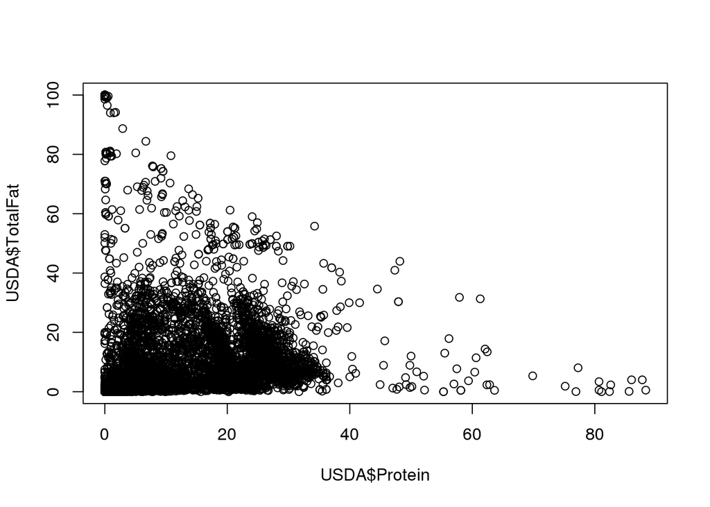

```r
plot(USDA$Protein,USDA$TotalFat)
```

The plot has a very interesting triangular shape, it looks like foods that are higher in protein are typically lower in fat and vice versa.

R gives default names for the axis. It’s possible to modify them adding more arguments to the plot function, add also a title and change the color

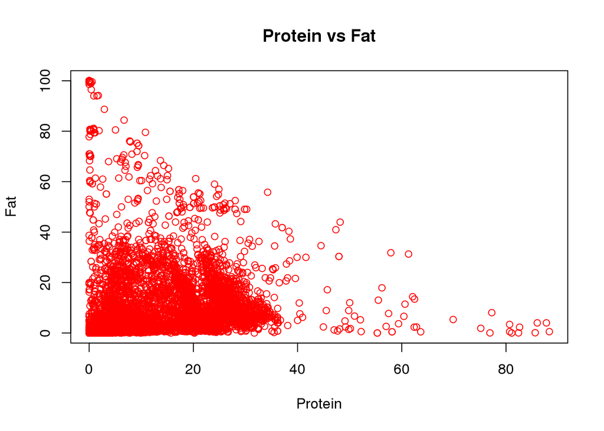

```r
plot(USDA$Protein,USDA$TotalFat, xlab="Protein", ylab="Fat", main="Protein vs Fat",col="red")
```

Another way to visualize data is by plotting histograms using the hist() function.

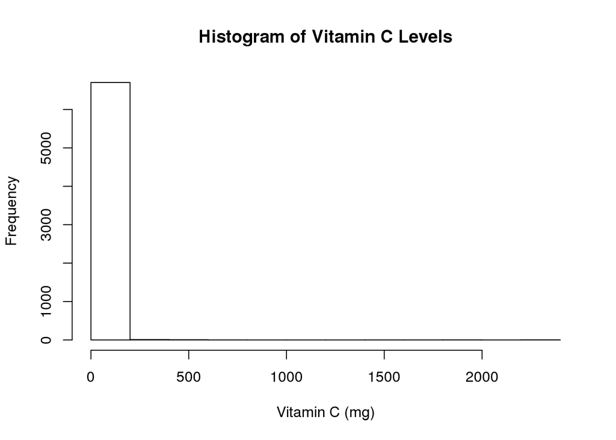

```r
hist(USDA$VitaminC, xlab="Vitamin C (mg)", main="Histogram of Vitamin C Levels")
```

The histogram groups them all together in one cell. In order to zoom in this section, it’s necessary to limit the x-axis to go from zero to 100 mg.

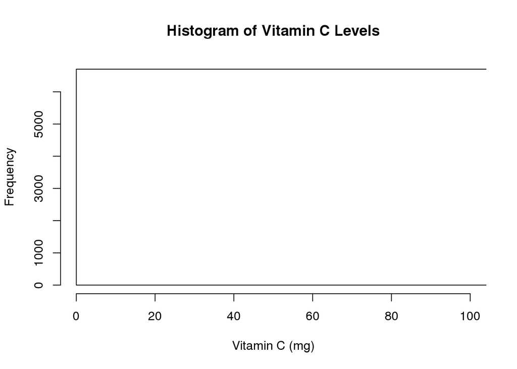

```r
hist(USDA$VitaminC, xlab="Vitamin C (mg)", main="Histogram of Vitamin C Levels",xlim=c(0,100))
```

But now there is only one big cell. To really break the cell into smaller pieces, it’s necessary to add the argument ‘breaks=’

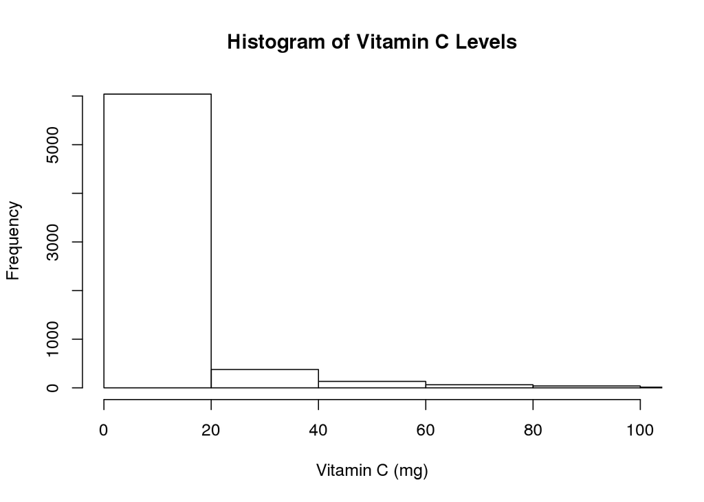

```r
hist(USDA$VitaminC, xlab="Vitamin C (mg)", main="Histogram of Vitamin C Levels",xlim=c(0,100),breaks=100)
```

There are actually only 5 cells and each cell is 20 mg long. This beacause the orginal interval, 0 to 2000 is divided into 100 cells, `2000/100=20`.

To correct this it’s needed to think in terms of the original interval and break it into 2000 cells.

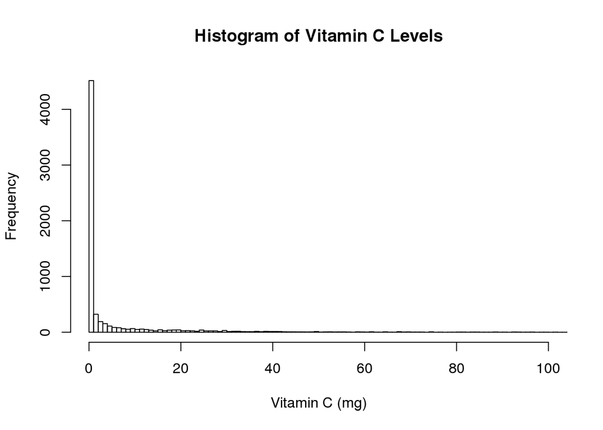

```r
hist(USDA$VitaminC, xlab="Vitamin C (mg)", main="Histogram of Vitamin C Levels",xlim=c(0,100),breaks=2000)
```

A third way to visualize data is using box plots using boxplot() function

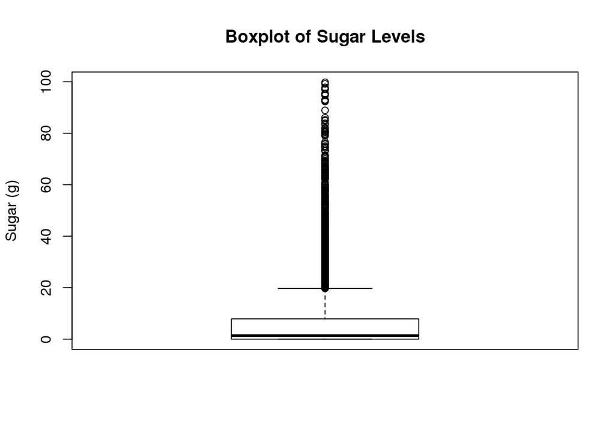

```r
boxplot(USDA$Sugar, main="Boxplot of Sugar Levels", ylab="Sugar (g)")
```

### Adding Variables

Suppose that it’s needed to add a variable in the USDA data frame that takes a value 1 if the food has higher sodium than average and 0 if the food has lower sodium than average.

Compare if a food has more sodium than the avearge, for example the first food Dont’t forget to remove the non-available entries.

```r
USDA$Sodium[1] > mean(USDA$Sodium, na.rm=TRUE) # TRUE
```

```
## [1] TRUE
```

```r
# What about the 50th food?
USDA$Sodium[50] > mean(USDA$Sodium, na.rm=TRUE) # FALSE
```

```
## [1] FALSE
```

It’s possible to write the same command on all the vector Sodium and save the results into a vector called HighSodium, then look at its structure.

```r
HighSodium = USDA$Sodium > mean(USDA$Sodium, na.rm=TRUE)
str(HighSodium)
```

```
##  logi [1:7058] TRUE TRUE FALSE TRUE TRUE TRUE ...
```

The vector has all these values TRUE and FALSE which are called logicals, so the type of the HighSodium vector is logical. But it’s expected to have 1 and 0 instead of TRUE and FALSE, to do this it exist the function as.numeric().

```r
HighSodium = as.numeric(USDA$Sodium > mean(USDA$Sodium, na.rm=TRUE))
str(HighSodium)
```

```
##  num [1:7058] 1 1 0 1 1 1 1 1 1 1 ...
```

This vector is not yet associated with the USDA data frame. To do this it, use the dollar notation.

```r
USDA$HighSodium = as.numeric(USDA$Sodium > mean(USDA$Sodium, na.rm=TRUE))
str(USDA)
```

```
## 'data.frame':    7058 obs. of  17 variables:
##  $ ID          : int  1001 1002 1003 1004 1005 1006 1007 1008 1009 1010 ...
##  $ Description : Factor w/ 7054 levels "ABALONE,MIXED SPECIES,RAW",..: 1311 1309 1307 2289 2290 2291 2292 2293 2294 2295 ...
##  $ Calories    : int  717 717 876 353 371 334 300 376 403 387 ...
##  $ Protein     : num  0.85 0.85 0.28 21.4 23.24 ...
##  $ TotalFat    : num  81.1 81.1 99.5 28.7 29.7 ...
##  $ Carbohydrate: num  0.06 0.06 0 2.34 2.79 0.45 0.46 3.06 1.28 4.78 ...
##  $ Sodium      : int  714 827 2 1395 560 629 842 690 621 700 ...
##  $ SaturatedFat: num  51.4 50.5 61.9 18.7 18.8 ...
##  $ Cholesterol : int  215 219 256 75 94 100 72 93 105 103 ...
##  $ Sugar       : num  0.06 0.06 0 0.5 0.51 0.45 0.46 NA 0.52 NA ...
##  $ Calcium     : int  24 24 4 528 674 184 388 673 721 643 ...
##  $ Iron        : num  0.02 0.16 0 0.31 0.43 0.5 0.33 0.64 0.68 0.21 ...
##  $ Potassium   : int  24 26 5 256 136 152 187 93 98 95 ...
##  $ VitaminC    : num  0 0 0 0 0 0 0 0 0 0 ...
##  $ VitaminE    : num  2.32 2.32 2.8 0.25 0.26 0.24 0.21 NA 0.29 NA ...
##  $ VitaminD    : num  1.5 1.5 1.8 0.5 0.5 0.5 0.4 NA 0.6 NA ...
##  $ HighSodium  : num  1 1 0 1 1 1 1 1 1 1 ...
```

It’s possible to do the same and add the variables HighProtein, HighCarbs, HighFat

```r
USDA$HighProtein = as.numeric(USDA$Protein > mean(USDA$Protein, na.rm=TRUE))
USDA$HighFat = as.numeric(USDA$TotalFat > mean(USDA$TotalFat, na.rm=TRUE))
USDA$HighCarbs = as.numeric(USDA$Carbohydrate > mean(USDA$Carbohydrate, na.rm=TRUE))
str(USDA)
```

```
## 'data.frame':    7058 obs. of  20 variables:
##  $ ID          : int  1001 1002 1003 1004 1005 1006 1007 1008 1009 1010 ...
##  $ Description : Factor w/ 7054 levels "ABALONE,MIXED SPECIES,RAW",..: 1311 1309 1307 2289 2290 2291 2292 2293 2294 2295 ...
##  $ Calories    : int  717 717 876 353 371 334 300 376 403 387 ...
##  $ Protein     : num  0.85 0.85 0.28 21.4 23.24 ...
##  $ TotalFat    : num  81.1 81.1 99.5 28.7 29.7 ...
##  $ Carbohydrate: num  0.06 0.06 0 2.34 2.79 0.45 0.46 3.06 1.28 4.78 ...
##  $ Sodium      : int  714 827 2 1395 560 629 842 690 621 700 ...
##  $ SaturatedFat: num  51.4 50.5 61.9 18.7 18.8 ...
##  $ Cholesterol : int  215 219 256 75 94 100 72 93 105 103 ...
##  $ Sugar       : num  0.06 0.06 0 0.5 0.51 0.45 0.46 NA 0.52 NA ...
##  $ Calcium     : int  24 24 4 528 674 184 388 673 721 643 ...
##  $ Iron        : num  0.02 0.16 0 0.31 0.43 0.5 0.33 0.64 0.68 0.21 ...
##  $ Potassium   : int  24 26 5 256 136 152 187 93 98 95 ...
##  $ VitaminC    : num  0 0 0 0 0 0 0 0 0 0 ...
##  $ VitaminE    : num  2.32 2.32 2.8 0.25 0.26 0.24 0.21 NA 0.29 NA ...
##  $ VitaminD    : num  1.5 1.5 1.8 0.5 0.5 0.5 0.4 NA 0.6 NA ...
##  $ HighSodium  : num  1 1 0 1 1 1 1 1 1 1 ...
##  $ HighProtein : num  0 0 0 1 1 1 1 1 1 1 ...
##  $ HighFat     : num  1 1 1 1 1 1 1 1 1 1 ...
##  $ HighCarbs   : num  0 0 0 0 0 0 0 0 0 0 ...
```

### Summary tables

Now we can try to understand the data and the relationships between variables using table() and tapply() functions.

To figure out how may foods have higher sodium level than average, look at the HighSodium variable and count the foods that have values 1.

```r
table(USDA$HighSodium) # most of the food have lower sodium than average
```

```
##
##    0    1
## 4884 2090
```

Look at how many foods have both high sodium and high fat

```r
table(USDA$HighSodium, USDA$HighFat)
```

```
##
##        0    1
##   0 3529 1355
##   1 1378  712
```

The rows belong to the first input (HighSodium) and the columns correspond to the second input (HighFat). Compute the average amount of iron sorted by high and low protein.

The tapply function takes three arguments:

`tapply(argument1, argument2, argument3)`

Group argument1 by argument2 and apply argument3

```r
tapply(USDA$Iron, USDA$HighProtein, mean, na.rm=TRUE)
```

```
##        0        1
## 2.558945 3.197294
```

How about the maximum level of vitamin C in food with high and low carbs.

```r
tapply(USDA$VitaminC, USDA$HighCarbs, max, na.rm=TRUE)
```

```
##      0      1
## 1677.6 2400.0
```

In order to further analyze these data use the summary function

```r
tapply(USDA$VitaminC, USDA$HighCarbs, summary, na.rm=TRUE)
```

```
## $`0`
##     Min.  1st Qu.   Median     Mean  3rd Qu.     Max.     NA's
##    0.000    0.000    0.000    6.364    2.800 1678.000      248
##
## $`1`
##    Min. 1st Qu.  Median    Mean 3rd Qu.    Max.    NA's
##    0.00    0.00    0.20   16.31    4.50 2400.00      83
```